# Q1 Supervised Learning

### 4. Fit the training dataset and optimize the hyperparameters of the method.

These are the hyperparameters that I am going to tune:

- n_estimators
- criterion
- max_depth
- min_samples_split
- min_samples_leaf
- class_weight
- ccp_alpha

###### Elbow-Method for class weight

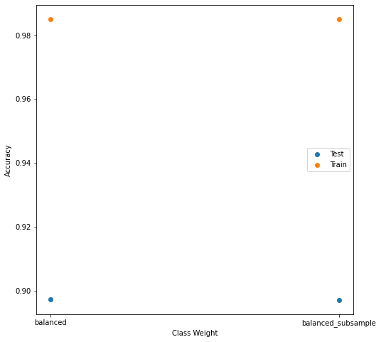

```python
classweight = ['balanced', 'balanced_subsample']

Train_Error_RandomForest = np.zeros(shape=(len(classweight),1))
Test_Error_RandomForest = np.zeros(shape=(len(classweight),1))

count = -1
for class_weight in classweight:
    count += 1
    # instantiate a tree classifier model, and fit with X and y
    RandomForest = RandomForestClassifier(class_weight = class_weight)
    # Fit the model
    RandomForest.fit(X_train_monthly, y_train_monthly)
    Train_Error_RandomForest[count,0] = RandomForest.score(X_train_monthly, y_train_monthly)
    Test_Error_RandomForest[count,0]  = RandomForest.score(X_test_monthly, y_test_monthly)

plt.scatter(classweight, Test_Error_RandomForest, label='Test')
plt.scatter(classweight, Train_Error_RandomForest, label='Train')
plt.xlabel('Class Weight')
plt.ylabel('Accuracy')
plt.legend()
plt.show()
```

Based on the graph above:

```
                        Best Class weight = 'balanced'
```

###### Elbow-Method for n-estimators

[figure not shown]

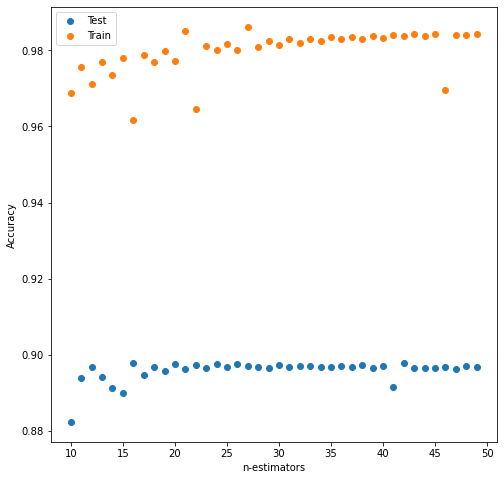

```python
nestimators = list(range(10,50))

Train_Error_RandomForest = np.zeros(shape=(len(nestimators),1))
Test_Error_RandomForest = np.zeros(shape=(len(nestimators),1))

count = -1
for n in nestimators:
    count += 1
    # instantiate a tree classifier model, and fit with X and y
    RandomForest = RandomForestClassifier(n_estimators = n,
                                          class_weight = 'balanced')
    # Fit the model
    RandomForest.fit(X_train_monthly, y_train_monthly)
    Train_Error_RandomForest[count,0] = RandomForest.score(X_train_monthly, y_train_monthly)
    Test_Error_RandomForest[count,0]  = RandomForest.score(X_test_monthly, y_test_monthly)

plt.scatter(nestimators, Test_Error_RandomForest, label='Test')
plt.scatter(nestimators, Train_Error_RandomForest, label='Train')
plt.xlabel('n-estimators')
plt.ylabel('Accuracy')
plt.legend()
plt.show()
```

Based on the graph above:

```
                       Best n-estimators = '18'
                       As the graph flatlines, the n-estimators will give the same accuracy no matter how
                       high we go thus, in order to give a decent processing time, 18 is choosen.
```

###### Elbow-Method for criterion

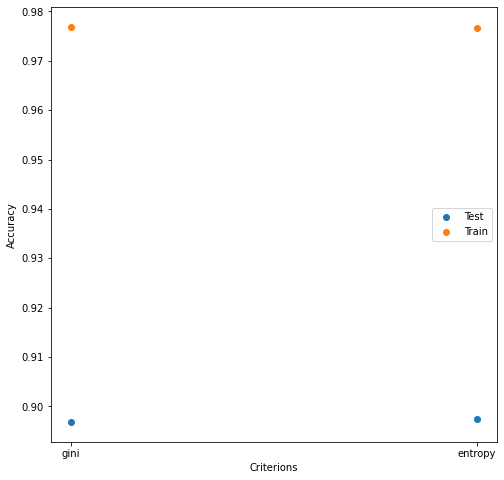

```python
criterions = ['gini', 'entropy']

Train_Error_RandomForest = np.zeros(shape=(len(criterions),1))
Test_Error_RandomForest = np.zeros(shape=(len(criterions),1))

count = -1
for criterion in criterions:
    count += 1
    # instantiate a tree classifier model, and fit with X and y
    RandomForest = RandomForestClassifier(n_estimators = 18,
                                          criterion = criterion,
                                          class_weight = 'balanced')
    # Fit the model
    RandomForest.fit(X_train_monthly, y_train_monthly)
    Train_Error_RandomForest[count,0] = RandomForest.score(X_train_monthly, y_train_monthly)
    Test_Error_RandomForest[count,0]  = RandomForest.score(X_test_monthly, y_test_monthly)

plt.scatter(criterions, Test_Error_RandomForest, label='Test')
plt.scatter(criterions, Train_Error_RandomForest, label='Train')
plt.xlabel('Criterions')
plt.ylabel('Accuracy')
plt.legend()
plt.show()
```

Based on the graph above:

[output not shown]

###### Elbow-Method for max_depth

[figure not shown]

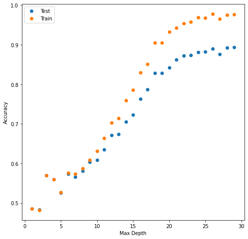

```python
maxdepth = list(range(1,30))

Train_Error_RandomForest = np.zeros(shape=(len(maxdepth),1))
Test_Error_RandomForest = np.zeros(shape=(len(maxdepth),1))

count = -1
for max_depth in maxdepth:
    count += 1
    # instantiate a tree classifier model, and fit with X and y
    RandomForest = RandomForestClassifier(n_estimators = 18,
                                          criterion = 'gini',
                                          max_depth = max_depth,
                                          class_weight = 'balanced')
    # Fit the model
    RandomForest.fit(X_train_monthly, y_train_monthly)
    Train_Error_RandomForest[count,0] = RandomForest.score(X_train_monthly, y_train_monthly)
    Test_Error_RandomForest[count,0]  = RandomForest.score(X_test_monthly, y_test_monthly)

plt.scatter(maxdepth, Test_Error_RandomForest, label='Test')
plt.scatter(maxdepth, Train_Error_RandomForest, label='Train')
plt.xlabel('Max Depth')
plt.ylabel('Accuracy')
plt.legend()
plt.show()
```

Based on the graph above:

[output not shown]

###### Elbow-Method for min_samples_split

This indicates the larger view of the min sample split, where we can see the accuracy decreases after a certain point.

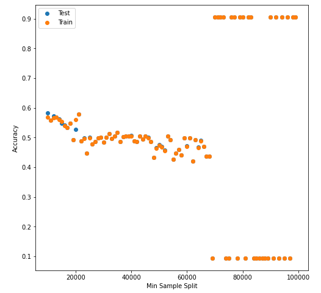

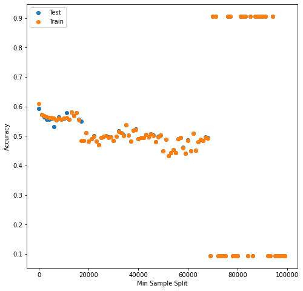

```python
minsamplesplit = list(range(2,100000,1000))

Train_Error_RandomForest = np.zeros(shape=(len(minsamplesplit),1))
Test_Error_RandomForest = np.zeros(shape=(len(minsamplesplit),1))

count = -1
for mss in minsamplesplit:
    count += 1
    # instantiate a tree classifier model, and fit with X and y
    RandomForest = RandomForestClassifier(n_estimators = 18,
                                          criterion = 'gini',
                                          max_depth = 9,
                                          min_samples_split = mss,
                                          class_weight = 'balanced')
    # Fit the model
    RandomForest.fit(X_train_monthly, y_train_monthly)
    Train_Error_RandomForest[count,0] = RandomForest.score(X_train_monthly, y_train_monthly)
    Test_Error_RandomForest[count,0]  = RandomForest.score(X_test_monthly, y_test_monthly)

plt.scatter(minsamplesplit, Test_Error_RandomForest, label='Test')
plt.scatter(minsamplesplit, Train_Error_RandomForest, label='Train')
plt.xlabel('Min Sample Split')
plt.ylabel('Accuracy')
plt.legend()
plt.show()
```

Based on the graph above:

[output not shown]

###### Elbow-Method for min_samples_leaf

The graphs below are different iterations of the min sample leaf to get the optimum value without overfitting.

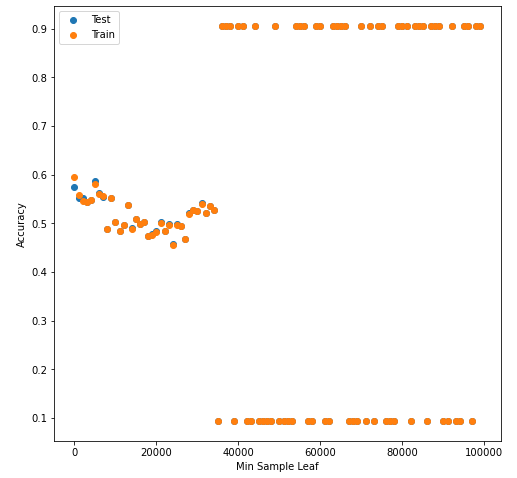

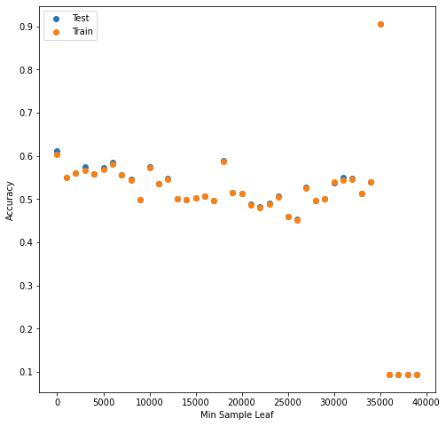

```python
minsampleleaf = list(range(1,40000,1000))

Train_Error_RandomForest = np.zeros(shape=(len(minsampleleaf),1))
Test_Error_RandomForest = np.zeros(shape=(len(minsampleleaf),1))

count = -1
for msl in minsampleleaf:
    count += 1
    # instantiate a tree classifier model, and fit with X and y
    RandomForest = RandomForestClassifier(n_estimators = 18,
                                          criterion = 'gini',
                                          max_depth = 9,
                                          min_samples_split = 2,
                                          min_samples_leaf = msl,
                                          class_weight = 'balanced')
    # Fit the model
    RandomForest.fit(X_train_monthly, y_train_monthly)
    Train_Error_RandomForest[count,0] = RandomForest.score(X_train_monthly, y_train_monthly)
    Test_Error_RandomForest[count,0]  = RandomForest.score(X_test_monthly, y_test_monthly)

plt.scatter(minsampleleaf, Test_Error_RandomForest, label='Test')
plt.scatter(minsampleleaf, Train_Error_RandomForest, label='Train')
plt.xlabel('Min Sample Leaf')
plt.ylabel('Accuracy')
plt.legend()
plt.show()
```

Based on the graph above:

[output not shown]

###### Elbow-Method for ccp alpha

The graphs below indicate the streamlining of the best value/range for ccp_alpha.

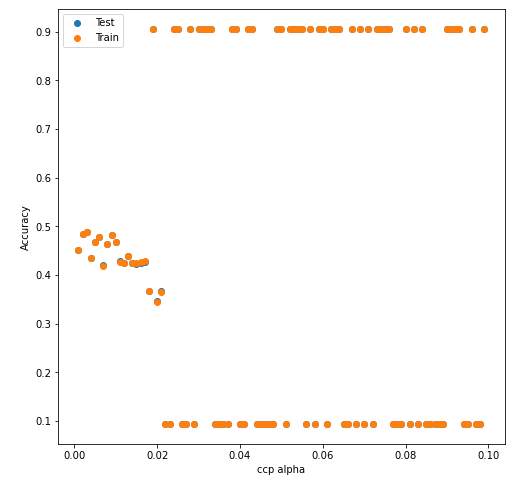

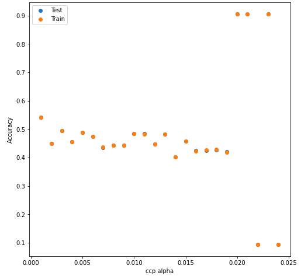

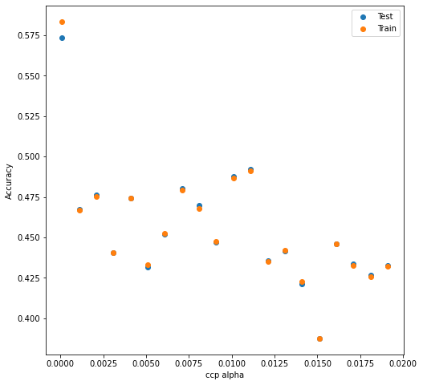

```python
ccpalpha = np.arange(0.0001,0.02,0.001)

Train_Error_RandomForest = np.zeros(shape=(len(ccpalpha),1))
Test_Error_RandomForest = np.zeros(shape=(len(ccpalpha),1))

count = -1
for ccp in ccpalpha:
    count += 1
    # instantiate a tree classifier model, and fit with X and y
    RandomForest = RandomForestClassifier(n_estimators = 18,
                                          criterion = 'gini',
                                          max_depth = 9,
                                          min_samples_split = 2,
                                          min_samples_leaf = 1,
                                          class_weight = 'balanced',
                                          ccp_alpha = ccp)
    # Fit the model
    RandomForest.fit(X_train_monthly, y_train_monthly)
    Train_Error_RandomForest[count,0] = RandomForest.score(X_train_monthly, y_train_monthly)
    Test_Error_RandomForest[count,0]  = RandomForest.score(X_test_monthly, y_test_monthly)

plt.scatter(ccpalpha, Test_Error_RandomForest, label='Test')
plt.scatter(ccpalpha, Train_Error_RandomForest, label='Train')
plt.xlabel('ccp alpha')
plt.ylabel('Accuracy')
plt.legend()
plt.show()
```

Based on the graph above:

```
                    Best ccp alpha = '0.0001'
                    As the accuracy decreases, same as the case for max deph and min samples.
```

```python
# Define and fit
Random_Forest = RandomForestClassifier(n_estimators = 18,
                                       criterion = 'gini',
                                       max_depth = 9,
                                       min_samples_split = 2,
                                       min_samples_leaf = 1,
                                       class_weight = 'balanced',
                                       ccp_alpha = 0.0001)
Random_Forest = Random_Forest.fit(X_train_monthly, y_train_monthly)
```

### 5. Plot coefficient values or feature importance.

```python
# Calculate feature importances
importances = Random_Forest.feature_importances_
importances
```

```
array([0.01493283, 0.002263  , 0.02810689, 0.02535609, 0.03075884,
       0.00507137, 0.00530717, 0.00367384, 0.09432517, 0.08940466,
       0.04433245, 0.0265698 , 0.01175395, 0.00407189, 0.17169108,
       0.16166916, 0.16240575, 0.02163168, 0.03492284, 0.00721893,
       0.00178917, 0.00237739, 0.0020482 , 0.00291502, 0.00180112,
       0.00154262, 0.00163275, 0.04042635])
```

```python
importances.shape
```

```
(28,)
```

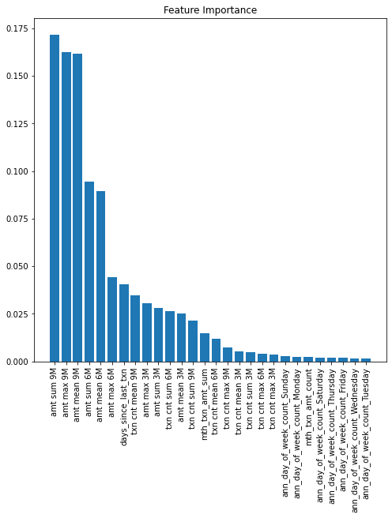

```python
# Sort feature importances in descending order
indices = np.argsort(importances)[::-1]

# Rearrange feature names so they match the sorted feature importances
names = [monthly_features_outputs.columns[i] for i in indices]

# Create plot
plt.figure()
# Create plot title
plt.title("Feature Importance")
# Add bars
plt.bar(range(X.shape[1]), importances[indices])
# Add feature names as x-axis labels
plt.xticks(range(X.shape[1]), names, rotation=90)
# Show plot
plt.show()
```

### 6. Plot probability distribution for test set.

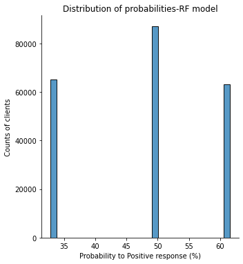

```python
plt.figure(figsize=(10,10))
sns.displot(data = 100*scores_test)
plt.title('Distribution of probabilities-RF model')
plt.xlabel('Probability to Positive response (%)')
plt.ylabel('Counts of clients')
```

### 7. Plot confusion matrix and ROC curves of train/test set. Calculate precision/recall.

### ROC Curve

```python
# Score train and test set ############### we don't need to store this in every iteration so we can overwrite it ###############
scores_train = Random_Forest.predict_proba(X_train_monthly)[:,1]
scores_test  = Random_Forest.predict_proba(X_test_monthly)[:,1]

# Predict the class of test set
y_test_predicted2 = Random_Forest.predict(X_test_monthly)

# Calculate accuracy at every iteration and append
accuracy = 100*accuracy_score(y_test_monthly, y_test_predicted2, normalize = True)

# ROC Calc Train set
fpr_train, tpr_train, _ = roc_curve(y_train_monthly, scores_train)

# ROC Calc Test set
fpr_test, tpr_test, _ = roc_curve(y_test_monthly, scores_test)

# Calculate the AUCs
auc_train = auc(fpr_train, tpr_train)
auc_test  = auc(fpr_test, tpr_test)
```

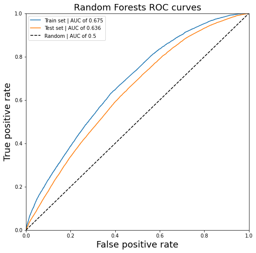

```python
# Plotting
plt.plot(fpr_train, tpr_train, label='Train set | AUC of {:4.3f}'.format(auc_train));
plt.plot(fpr_test, tpr_test, label='Test set | AUC of {:4.3f}'.format(auc_test));
plt.plot([0,1], [0,1], color = 'k', linestyle = '--', label = 'Random | AUC of 0.5');
plt.ylim([0,1.0])
plt.xlim([0,1.0])
plt.title('Random Forests ROC curves', fontsize = 18)
plt.ylabel('True positive rate', fontsize = 18)
plt.xlabel('False positive rate', fontsize = 18)
plt.legend()
plt.show()
```

### Confusion Matrix

```python
cm2 = confusion_matrix(y_test_monthly, y_test_predicted2)
print(cm2)
```

```
[[115015  80382]
 [  8048  12254]]
```

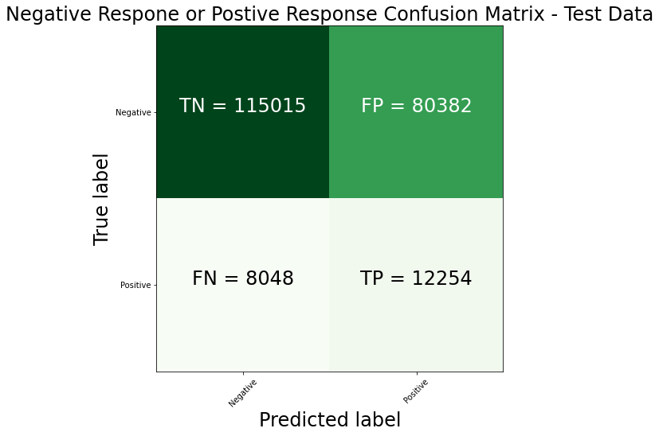

```python
plt.clf()
plt.imshow(cm2, interpolation='nearest', cmap=plt.cm.Greens)
classNames = ['Negative','Positive']
plt.title('Negative Respone or Postive Response Confusion Matrix - Test Data', fontsize = 24)
plt.ylabel('True label', fontsize = 24)
plt.xlabel('Predicted label', fontsize = 24)
tick_marks = np.arange(len(classNames))
plt.xticks(tick_marks, classNames, rotation=45)
plt.yticks(tick_marks, classNames)
s = [['TN','FP'], ['FN', 'TP']]
thresh = cm2.max() / 2.
for i in range(2):
    for j in range(2):
        plt.text(j,i, str(s[i][j])+" = "+str(cm2[i][j]), fontsize = 24,
                 horizontalalignment="center",
                 color="white" if cm2[i, j] > thresh else "black")
plt.show()
```

#### Classification Report

```python
print(classification_report(y_test_monthly, y_test_predicted2, target_names = ['Positive Response', 'Negative Response']))
```

[output not shown]

#### Accuracy Score

```python
# Change normalize = True/False as well. DIAGONAL OVER ALL
accuracy_score(y_test_monthly, y_test_predicted2, normalize = True)
```

```
0.5900305518338055
```

```python
xx, yy = np.mgrid[-2:8:1.1111, -2:8:1.1111] # The steps 1.1111 and 1.75 were selected to create a 10x10 grid
grid = np.c_[xx.ravel(), yy.ravel()]
print(grid.shape) # Confirm that grid shape is 10x10

# np.ones is a table full of ones with 100x75 dimension
# np.median calculates the median of every column in the X_train along axis=0 (i.e. column)
median_inputs = np.ones((100, 28)) * np.median(X_train_monthly, axis=0)
pd.DataFrame(median_inputs) # Convert to pandas is not necessary. Just doing it here to have a nice view of the table

# Then, we replace the 5th and 11th column with the values of the grid
median_inputs[:,14] = grid[:,0]
median_inputs[:,15] = grid[:,1]
df = pd.DataFrame(median_inputs).iloc[:12,:34] # Convert to pandas is not necessary. Just doing it here to have a nice view of the table
df.style.apply(lambda x: ['background: grey' if (x.name == 14)|(x.name == 15)  else '' for i in x])
```

```
(100, 2)
```

|  | 0 | 1 | 2 | 3 | 4 | 5 | 6 | 7 | 8 | 9 | 10 | 11 | 12 | 13 | 14 | 15 | 16 | 17 | 18 | 19 | 20 | 21 | 22 | 23 | 24 | 25 | 26 | 27 |
| --- | --- | --- | --- | --- | --- | --- | --- | --- | --- | --- | --- | --- | --- | --- | --- | --- | --- | --- | --- | --- | --- | --- | --- | --- | --- | --- | --- | --- |
| 0 | 0.000000 | 0.000000 | 66.000000 | 22.000000 | 58.845348 | 1.000000 | 0.333333 | 1.000000 | 152.000000 | 25.333333 | 86.887242 | 2.000000 | 0.333333 | 1.000000 | -2.000000 | -2.000000 | 102.864562 | 3.542333 | 0.393593 | 1.462211 | 0.000000 | 0.000000 | 0.000000 | 0.000000 | 0.000000 | 0.000000 | 0.000000 | 46.000000 |
| 1 | 0.000000 | 0.000000 | 66.000000 | 22.000000 | 58.845348 | 1.000000 | 0.333333 | 1.000000 | 152.000000 | 25.333333 | 86.887242 | 2.000000 | 0.333333 | 1.000000 | -2.000000 | -0.888900 | 102.864562 | 3.542333 | 0.393593 | 1.462211 | 0.000000 | 0.000000 | 0.000000 | 0.000000 | 0.000000 | 0.000000 | 0.000000 | 46.000000 |
| 2 | 0.000000 | 0.000000 | 66.000000 | 22.000000 | 58.845348 | 1.000000 | 0.333333 | 1.000000 | 152.000000 | 25.333333 | 86.887242 | 2.000000 | 0.333333 | 1.000000 | -2.000000 | 0.222200 | 102.864562 | 3.542333 | 0.393593 | 1.462211 | 0.000000 | 0.000000 | 0.000000 | 0.000000 | 0.000000 | 0.000000 | 0.000000 | 46.000000 |
| 3 | 0.000000 | 0.000000 | 66.000000 | 22.000000 | 58.845348 | 1.000000 | 0.333333 | 1.000000 | 152.000000 | 25.333333 | 86.887242 | 2.000000 | 0.333333 | 1.000000 | -2.000000 | 1.333300 | 102.864562 | 3.542333 | 0.393593 | 1.462211 | 0.000000 | 0.000000 | 0.000000 | 0.000000 | 0.000000 | 0.000000 | 0.000000 | 46.000000 |
| 4 | 0.000000 | 0.000000 | 66.000000 | 22.000000 | 58.845348 | 1.000000 | 0.333333 | 1.000000 | 152.000000 | 25.333333 | 86.887242 | 2.000000 | 0.333333 | 1.000000 | -2.000000 | 2.444400 | 102.864562 | 3.542333 | 0.393593 | 1.462211 | 0.000000 | 0.000000 | 0.000000 | 0.000000 | 0.000000 | 0.000000 | 0.000000 | 46.000000 |
| 5 | 0.000000 | 0.000000 | 66.000000 | 22.000000 | 58.845348 | 1.000000 | 0.333333 | 1.000000 | 152.000000 | 25.333333 | 86.887242 | 2.000000 | 0.333333 | 1.000000 | -2.000000 | 3.555500 | 102.864562 | 3.542333 | 0.393593 | 1.462211 | 0.000000 | 0.000000 | 0.000000 | 0.000000 | 0.000000 | 0.000000 | 0.000000 | 46.000000 |
| 6 | 0.000000 | 0.000000 | 66.000000 | 22.000000 | 58.845348 | 1.000000 | 0.333333 | 1.000000 | 152.000000 | 25.333333 | 86.887242 | 2.000000 | 0.333333 | 1.000000 | -2.000000 | 4.666600 | 102.864562 | 3.542333 | 0.393593 | 1.462211 | 0.000000 | 0.000000 | 0.000000 | 0.000000 | 0.000000 | 0.000000 | 0.000000 | 46.000000 |
| 7 | 0.000000 | 0.000000 | 66.000000 | 22.000000 | 58.845348 | 1.000000 | 0.333333 | 1.000000 | 152.000000 | 25.333333 | 86.887242 | 2.000000 | 0.333333 | 1.000000 | -2.000000 | 5.777700 | 102.864562 | 3.542333 | 0.393593 | 1.462211 | 0.000000 | 0.000000 | 0.000000 | 0.000000 | 0.000000 | 0.000000 | 0.000000 | 46.000000 |
| 8 | 0.000000 | 0.000000 | 66.000000 | 22.000000 | 58.845348 | 1.000000 | 0.333333 | 1.000000 | 152.000000 | 25.333333 | 86.887242 | 2.000000 | 0.333333 | 1.000000 | -2.000000 | 6.888800 | 102.864562 | 3.542333 | 0.393593 | 1.462211 | 0.000000 | 0.000000 | 0.000000 | 0.000000 | 0.000000 | 0.000000 | 0.000000 | 46.000000 |
| 9 | 0.000000 | 0.000000 | 66.000000 | 22.000000 | 58.845348 | 1.000000 | 0.333333 | 1.000000 | 152.000000 | 25.333333 | 86.887242 | 2.000000 | 0.333333 | 1.000000 | -2.000000 | 7.999900 | 102.864562 | 3.542333 | 0.393593 | 1.462211 | 0.000000 | 0.000000 | 0.000000 | 0.000000 | 0.000000 | 0.000000 | 0.000000 | 46.000000 |
| 10 | 0.000000 | 0.000000 | 66.000000 | 22.000000 | 58.845348 | 1.000000 | 0.333333 | 1.000000 | 152.000000 | 25.333333 | 86.887242 | 2.000000 | 0.333333 | 1.000000 | -0.888900 | -2.000000 | 102.864562 | 3.542333 | 0.393593 | 1.462211 | 0.000000 | 0.000000 | 0.000000 | 0.000000 | 0.000000 | 0.000000 | 0.000000 | 46.000000 |
| 11 | 0.000000 | 0.000000 | 66.000000 | 22.000000 | 58.845348 | 1.000000 | 0.333333 | 1.000000 | 152.000000 | 25.333333 | 86.887242 | 2.000000 | 0.333333 | 1.000000 | -0.888900 | -0.888900 | 102.864562 | 3.542333 | 0.393593 | 1.462211 | 0.000000 | 0.000000 | 0.000000 | 0.000000 | 0.000000 | 0.000000 | 0.000000 | 46.000000 |

```python
probs = Random_Forest.predict_proba(median_inputs)[:, 1].reshape(xx.shape)
```

[output not shown]

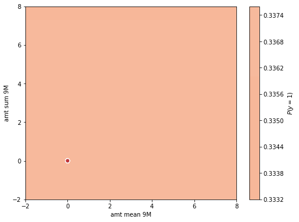

```python
f, ax = plt.subplots(figsize=(8, 6))
contour = ax.contourf(xx, yy, probs, 25, cmap="RdBu",
                      vmin=0, vmax=1)
ax_c = f.colorbar(contour)
ax_c.set_label("$P(y = 1)$")
# ax_c.set_ticks([0, .25, .5, .75, 1])

ax.scatter(X_train_monthly['amt mean 9M'][50:], X_train_monthly['amt sum 9M'][50:], c=y_train_monthly[50:], s=50,
           cmap="RdBu", vmin=-.2, vmax=1.2,
           edgecolor="white", linewidth=1)
# plt.annotate('P = 45.0%', xy=(5,0), xycoords='data',horizontalalignment= 'center', verticalalignment= 'center', fontsize = 14)
# plt.annotate('P = 12.8%', xy=(-0.8,0.35), xycoords='data', horizontalalignment= 'center', fontsize = 14)
# plt.annotate('P = 27.2%', xy=(-0.8,6.0), xycoords='data', horizontalalignment= 'center', verticalalignment= 'center', fontsize = 14)
# plt.annotate('P = 55.1%', xy=(6.0,3.0), xycoords='data', horizontalalignment= 'center', verticalalignment= 'center', fontsize = 14)
# plt.annotate('P = 27.2%', xy=(7.0,4.5), xycoords='data', horizontalalignment= 'center', verticalalignment= 'center', fontsize = 14)

ax.set(aspect="auto",
       xlim=(-2, 8), ylim=(-2, 8),
       xlabel="amt mean 9M", ylabel="amt sum 9M")
```

## 1.3 Comparison of methods (10 points)

##### Comparision in the Annual Model File.